# Exercise 3 — Point Patterns in Space and Space-Time

BSTA 374 · 25 points · Due Sunday, October 4, 2026, 11:59 pm

Author

Danny Lim · Lehigh University

Published

October 8, 2026

## What this exercise is

The largest lab of the semester. You will decide whether a set of case locations is clustered, at what spatial scale, where the intensity is highest, and whether the clustering is also concentrated in *time* — which is a different claim, and the one that matters for an outbreak.

**Data.** Two files, posted with this exercise. Put them in a `data/` folder beside your `.qmd`.

| File | What it holds |
| --- | --- |
| `dengue_cases_sim.csv` | 500 simulated dengue cases: `case_id`, `onset_date`, `report_date`, `neighborhood`, `age_group`, `lon`, `lat` |
| `study_area.geojson` | the study-area boundary polygon |

These are **simulated** data modelled on a dengue surveillance setting. Nobody’s health information is involved, and the generating process is known — which means your conclusions can be checked.

Each part ends with **starting code**: copy it, fill in the blanks marked `______`, and adapt. It is scaffolding, not a solution.

**ImportantSubmission**

Two things. Submit `LASTNAME_FI_Exercise3.qmd` — the source — to Course Site, with your name in the document header. And publish the rendered HTML to your semester GitHub repository, then paste the live URL into the Course Site submission — Part H is that second step, and it is the one that carries the point.

**WarningReproducibility is graded**

Restart R and render from a clean session before submitting. Several parts involve simulation — set a seed at the top and use it, or your numbers will change between the render you checked and the render I grade.

```r
library(sf)
library(dplyr)
library(ggplot2)
library(spatstat)
library(splancs)      # space-time K function
library(plotly)       # space-time cube
set.seed(7)      # your student ID works
```

## Part A — From CSV to `ppp` (3 points)

Everything after this part runs on a `ppp` object, so it is worth knowing what one is. `spatstat` does not work with `sf`. A **`ppp`** (“planar point pattern”) holds two things: the coordinates of the events, and a **window** — the region within which they could have been observed. Both are required, because every statistic in this lab is a comparison against what would be expected inside that window: the intensity is $n$ divided by its area, the expected nearest-neighbour distance depends on that intensity, and the edge corrections depend on its shape. Give `spatstat` the wrong window and every number below changes without any warning.

1. Read the case file and the boundary. Report how many cases you have and what one row represents.

   A:The number of cases I have is 500 cases total and each row represents one dengue case.
2. Convert the cases to an `sf` object in **EPSG:4326**, then project both the cases and the boundary to **EPSG:32618** (UTM 18N, metres). One sentence on why the analysis cannot be done in degrees.

   A: Analysis cant be done in degrees because space calculations need distance measurements rather than angles.
3. Build a `ppp` whose window is the study-area polygon, then print it. Report the number of events and the intensity in cases per km².

   A: ppp has 500 events and the intensity in cases per km^2 is 2.63.
4. Replace the polygon window with the bounding box of the cases (`Window(pp) <- owin(range(x), range(y))`) and recompute the intensity. Two or three sentences on how much it changed and why the choice of window is a modelling decision rather than a technicality. Then go back to the polygon.

   A:The bounding box has a larger area than the study area polygon, as the intensity decreased from 2.63 to 2.35. The choice of window is a modelling decision rather than a technicality because the bounding box increased the area, which increased the denominator and caused the intensity to decrease
5. Map the cases over the boundary.

### Starting code

```r
cases_raw <- read.csv("data/dengue_cases_sim.csv", stringsAsFactors = FALSE)
area <- st_read("data/study_area.geojson", quiet = TRUE) |> st_transform(32618)

cases <- cases_raw |>
  mutate(onset_date  = as.Date(onset_date),
         report_date = as.Date(report_date)) |>
  st_as_sf(coords = c("lon", "lat"), crs = 4326) |>
  st_transform(32618)

win <- as.owin(st_geometry(area))       # the observation window
pp  <- as.ppp(st_geometry(cases))       # coordinates only, with a bounding box
Window(pp) <- win                       # attach the real window

pp                                      # print it: n, window type, extent
```

```
Planar point pattern: 500 points
window: polygonal boundary
enclosing rectangle: [323369.6, 338361.5] x [372065.1, 388098.9] units
```

```r
npoints(pp)
```

```
[1] 500
```

```r
intensity(pp) * 1e6                     # cases per km^2
```

```
[1] 2.626777
```

```r
x <- pp$x
y <- pp$y
pp_box<- pp
Window(pp_box) <- owin(range(x), range(y))
intensity(pp_box) * 1e6
```

```
[1] 2.348006
```

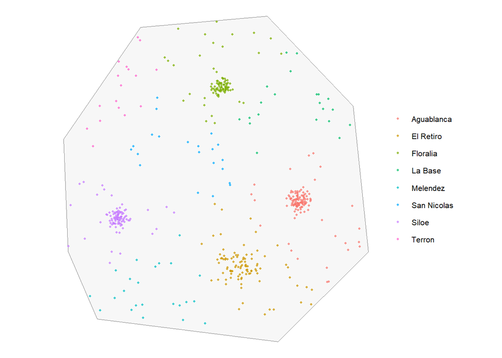

```r
ggplot() +
  geom_sf(data = area, fill = "grey97", colour = "grey50") +
  geom_sf(data = cases, aes(colour = neighborhood), size = 0.8, alpha = 0.7) +
  labs(colour = NULL) +
  theme_void(base_size = 10)
```

## Part B — Quadrat analysis (3 points)

1. Lay a 6 × 6 grid over the window, map the counts, and compute the mean, variance and **variance-to-mean ratio** from the counts by hand — not from a canned function. Show the arithmetic.

   A: Mean - 13.89 Variance - 581.70 VMR - 41.88
2. State what the VMR is being compared against, and why: under complete spatial randomness the counts are Poisson, and a Poisson distribution has variance equal to its mean. Report where your value sits relative to 1.

   A: The VMR is being compared against 1 because counts follow a Poisson distribution where the variance equals the mean.My VMR is 41.88, which is greater than 1.
3. Repeat the VMR for at least four grid resolutions and plot VMR against cells per side. Three or four sentences: what does the shape of that curve say about the claim “this pattern is clustered”?

   A: The VMR stays greater than 1 for all grid resolutions, which shows that the pattern is clustered.Even though the VMR changes depending on the grid size, it stays above 1 in every case. This means the overall pattern is clustered in all the grid resolutions.

### Starting code

```r
qc  <- quadratcount(pp, nx = 6, ny = 6)
cnt <- as.vector(qc)

c(k = length(cnt), mean = mean(cnt), var = var(cnt), VMR = var(cnt)/mean(cnt))
```

```
        k      mean       var       VMR
 36.00000  13.88889 581.70159  41.88251
```

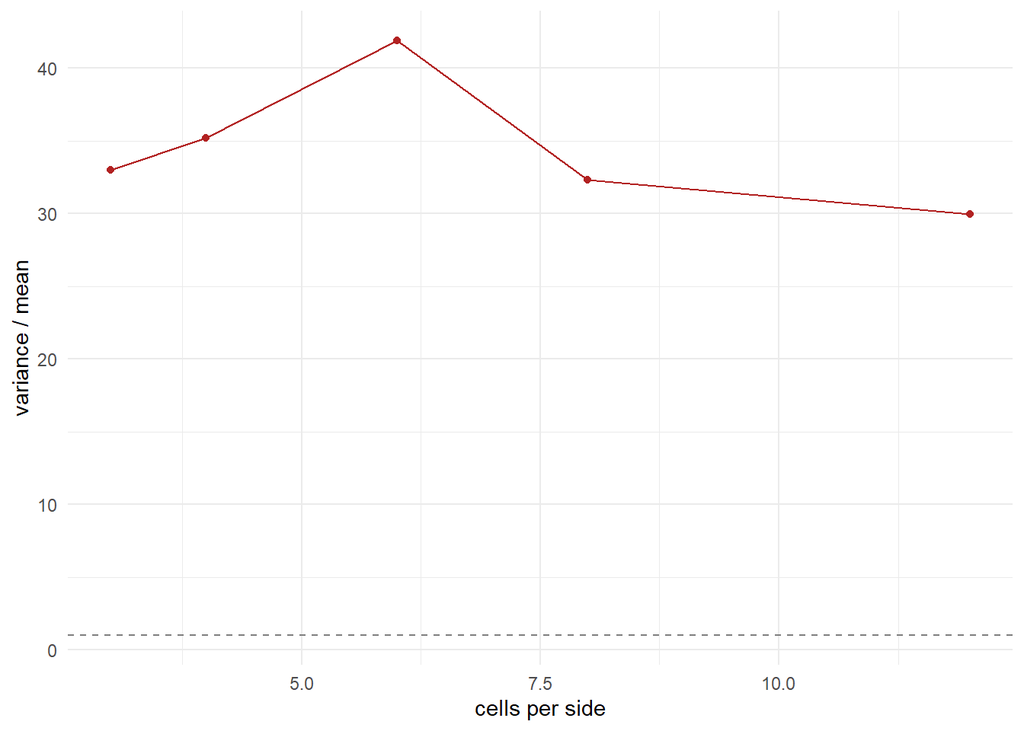

```r
grid_n <- c(3, 4, 6, 8, 12)
vmr <- sapply(grid_n, function(k) {
  v <- as.vector(quadratcount(pp, nx = k, ny = k))
  var(v)/mean(v)
})

data.frame(cells = grid_n, vmr = vmr) |>
  ggplot(aes(cells, vmr)) +
  geom_hline(yintercept = 1, linetype = 2, colour = "grey50") +
  geom_line(colour = "firebrick") +
  geom_point(colour = "firebrick") +
  labs(x = "cells per side", y = "variance / mean") +
  theme_minimal()
```

## Part C — Nearest-neighbour statistics (3 points)

1. Compute `nndist()`, report the observed mean, and compute the CSR expectation $E(d) = 1/(2\sqrt{\lambda})$ **by hand** from your intensity. Report the Clark–Evans ratio $R$ and state the direction of the departure.

   A: The observed mean was 215.52. The CSR expectation valye was 308.5. The clark evans ratio was 0.699. Since it is less than 1, the observed points are clustered together.
2. Run `clarkevans.test()` with a Monte Carlo null. The window is an irregular polygon, so the Donnelly correction is unavailable — use `correction = "cdf"` with `method = "MonteCarlo"`. One sentence on why an edge correction is needed at all.

   A: Edge Correction is needed to make it minimizes bias in nearest neighbors.
3. Plot the G function with a simulation envelope. Two or three sentences on what G shows that the single ratio $R$ does not.

   A: The G function shows nearest neighbor clustering in a range of distances, while the Clark-Evans ratio gives only one value.The observed G curve is above the simulation envelope for much of the distance range, which shows clustering at multiple distances.

### Starting code

```r
nnd    <- nndist(pp)
lambda <- intensity(pp)
d_exp  <- 1 / (2 * sqrt(lambda))                        # 1 / (2 sqrt(lambda))

c(observed = mean(nnd), expected = d_exp, R = mean(nnd) / d_exp)
```

```
   observed    expected           R
215.5165165 308.5023198   0.6985896
```

```r
clarkevans.test(pp, correction = "cdf", alternative = "clustered",
                method = "MonteCarlo", nsim = 99)
```

```
    Clark-Evans test
    CDF correction
    Monte Carlo test based on 99 simulations of CSR with fixed n

data:  pp
R = 0.65464, p-value = 0.01
alternative hypothesis: clustered (R < 1)
```

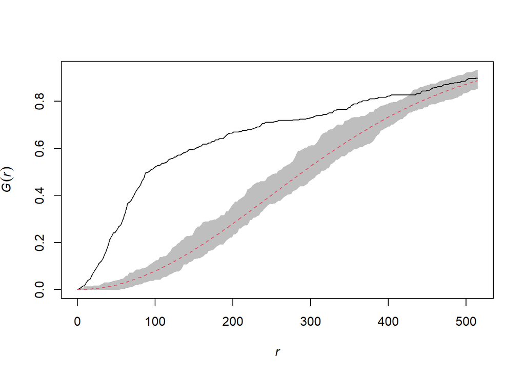

```r
plot(envelope(pp, Gest, nsim = 39, verbose = FALSE), main = "", legend = FALSE)
```

## Part D — Ripley’s K across scales (4 points)

1. Estimate $K(r)$ with an edge correction, then plot the centred L function $\hat{L}(r) - r$ against $r$.
2. Add a **simultaneous** envelope (`global = TRUE`) from at least 99 CSR simulations. State the distances over which the curve leaves the band.

   A: The centered L curve leaves the CSR envelope from about 22 m to 3748 m. This means the cases are more clustered than expected
3. Read a **characteristic scale** off the curve — the $r$ at which the departure peaks — and translate it into something a public health officer would recognise: a few city blocks, a neighbourhood, half the city.

   A:The strongest departure occurs at about 791 m, which is roughly the scale of a neighborhood. This means the strongest clustering appears to occur at about the neighborhood scale
4. Three or four sentences: $K$ assumes the intensity is constant across the window. Looking at your map from Part A, is that plausible here? Say what the consequence is for reading the curve — what else, besides interaction between cases, could put it above the envelope.

   A: Constant intensity is not plausible because some parts of the study area have many more cases than others. This means the L curve being above the CSR envelope may be partly caused by cases being more common in certain areas, not only by the cases clustering close to each other. So the result should be interpreted carefully

**Warning**

`global = TRUE` with `nsim = 99` takes a minute or two. Develop with `nsim = 19`, raise it once, and do not re-render in a loop.

### Starting code

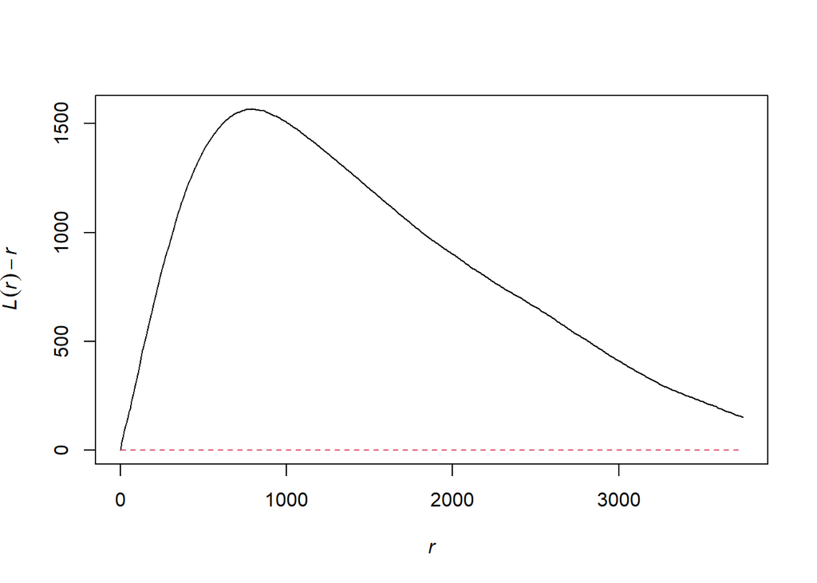

```r
L <- Lest(pp, correction = "isotropic")
plot(L, . - r ~ r, main = "", legend = FALSE)
```

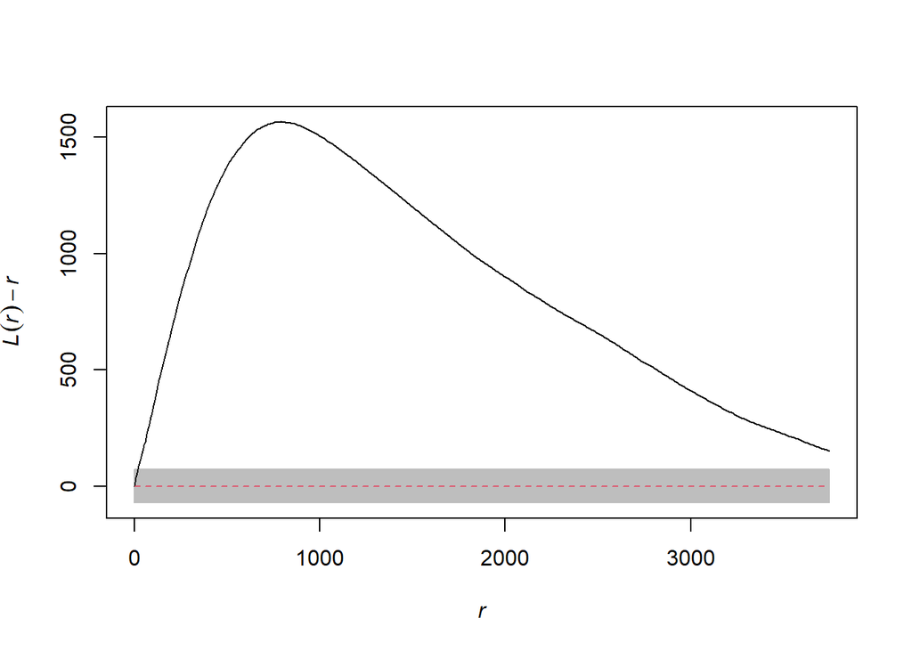

```r
env <- envelope(pp, Lest, nsim = 99, correction = "isotropic",
                global = TRUE, verbose = FALSE)
plot(env, . - r ~ r, main = "", legend = FALSE)
```

## Part E — Kernel density estimation and bandwidth choice (4 points)

K tells you *whether* and *at what distance*; it does not tell you *where*. That is what a kernel intensity surface is for.

1. Estimate the intensity with `density.ppp()` and convert to **cases per km²**. Map it with the cases drawn on top.
2. Produce the same surface at **three bandwidths** — one clearly too small, one clearly too large, and one you would defend — on a **common colour scale** so the panels are comparable. Two or three sentences on what changes and what does not.

   A: The smaller bandwidth shows that the hotspots are more concentrated and broken into smaller areas, while the larger bandwidth makes them look smoother. The 470 m bandwidth still shows the main hotspots clearly without erasing the hotspots.
3. Compare at least two automatic selectors (`bw.diggle()`, `bw.ppl()`, `bw.scott()`). Report the values in metres, say which you adopt and why, and note whether your answer to step 2 would change if you adopted a different one.

   A:A: The automatic bandwidths were 168.7 m for Diggle, 469.9 m for PPL, and 1250.5 m for Scott. I would use 470 m because it shows the main hotspots clearly without erasing the hot spots or making them hard to see.If I used a different bandwidth, the amount of smoothing would change, but the main hotspot locations would still be similar.
4. Three or four sentences on what this map is and is not. Where is the intensity highest? What would you need in order to turn this surface into a statement about **risk** rather than about counts, and what is the name of the quantity you would compute instead?

   A:This map shows where dengue cases are most concentrated, but it does not directly show the risk of getting dengue. The intensity is highest in the main hotspot areas where the cases are grouped closely together. To measure risk, I would also need to know about the at risk in each area. Then I could calculate the rate to demonstrate the exact risk.

**TipWhat earns full marks here**

Step 4, and the common colour scale in step 2. Two surfaces at different bandwidths with independently stretched legends look like different data; a reader cannot compare them, and neither can you.

### Starting code

```r
sig <- bw.diggle(pp)
c(diggle = bw.diggle(pp), ppl = bw.ppl(pp), scott = mean(bw.scott(pp)))
```

```
   diggle       ppl     scott
 168.6955  469.9289 1250.5481
```

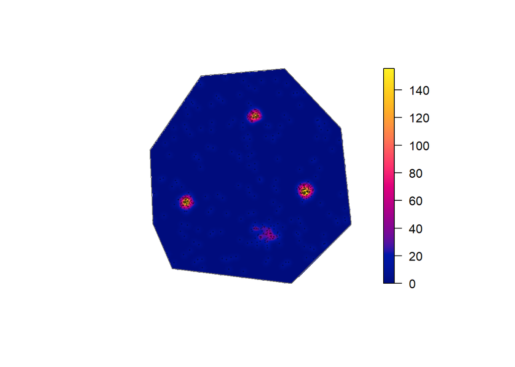

```r
kde <- density(pp, sigma = sig, eps = 50) * 1e6       # cases per km^2
plot(kde, main = "", ribargs = list(las = 1))
plot(Window(pp), add = TRUE, border = "grey40")
points(pp, pch = 16, cex = 0.25, col = rgb(0, 0, 0, 0.35))
```

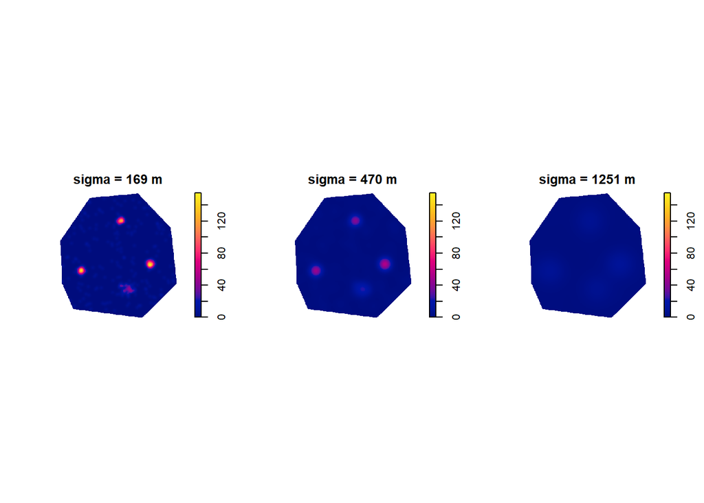

```r
sigmas <- c(169, 470, 1251)                   # too small, defensible, too large
surf   <- lapply(sigmas, function(s) density(pp, sigma = s, eps = 50) * 1e6)
zmax   <- max(sapply(surf, max))                      # one scale for all panels

par(mfrow = c(1, 3))
for (i in seq_along(surf))
  plot(surf[[i]], main = paste0("sigma = ", sigmas[i], " m"), zlim = c(0, zmax))
```

## Part F — Space-time kernel density (3 points)

A single intensity surface pools six months. An outbreak is a hotspot that exists in some weeks and not others, and pooling hides exactly that.

1. Split the cases into **monthly** patterns and estimate a kernel surface for each, using **one bandwidth for all months** and **one colour scale for all months**. Display them as small multiples.
2. Two or three sentences on why both of those constraints are necessary, and what a reader would wrongly conclude if each panel were scaled to its own maximum.

   A: : Using the same bandwidth for every month is important because it keeps the amount of smoothing consistent. Using the same color scale is also important because it lets the monthly maps be compared fairly. If each month used its own maximum color scale, a month with low intensity could look just as strong as a month with much higher intensity
3. Name the months and locations where the intensity is high, and say which hotspots persist across months and which appear and disappear.

   A: The highest intensity occurs in February in the northern part of the study area, March in the eastern part, and May in the western part. These strong hotspots are not present in all months because they appear strongly in one month and then fade or disappear in the others. January, April, and June show lower intensity. This shows that the strongest hotspots are mostly temporary rather than persistent across the six months.
4. Build a **space-time cube**: an interactive 3D scatter with easting, northing and day-of-study on the three axes, coloured by neighbourhood. Rotate it until the structure is visible, then set a viewing angle that makes your point and keep it. One or two sentences on what the cube shows that the small multiples do not, and vice versa — look in particular for the difference between a compact blob and a vertical column.

   A:The space-time cube shows whether cases stay in the same location over time or occur during a shorter period. A vertical column shows cases continuing in the same location over a longer time, while a compact blob shows cases clustered in both space and time.

**Warningplotly renders in HTML only**

The cube is an HTML widget: it appears in an HTML render and is silently dropped from a PDF one. The two chunks below are gated on `knitr::is_html_output()`, so whichever format you render gets a working figure. If you publish the HTML, keep `embed-resources: true` — otherwise the widget lives in a `_files/` folder that has to travel with the page.

**NoteIf you want the proper estimator**

Steps 1–3 are a discretised space-time KDE: one spatial bandwidth, and a temporal “bandwidth” equal to one month, applied as a hard cut. The continuous version smooths in time as well, with a separate temporal bandwidth, and lives in the `sparr` package — `spattemp.density()` with `h` and `lambda`, then `spattemp.slice()` to pull out time slices. Using it is worth up to **2 bonus points** if the monthly version is already complete and correct. Do not start here.

### Starting code

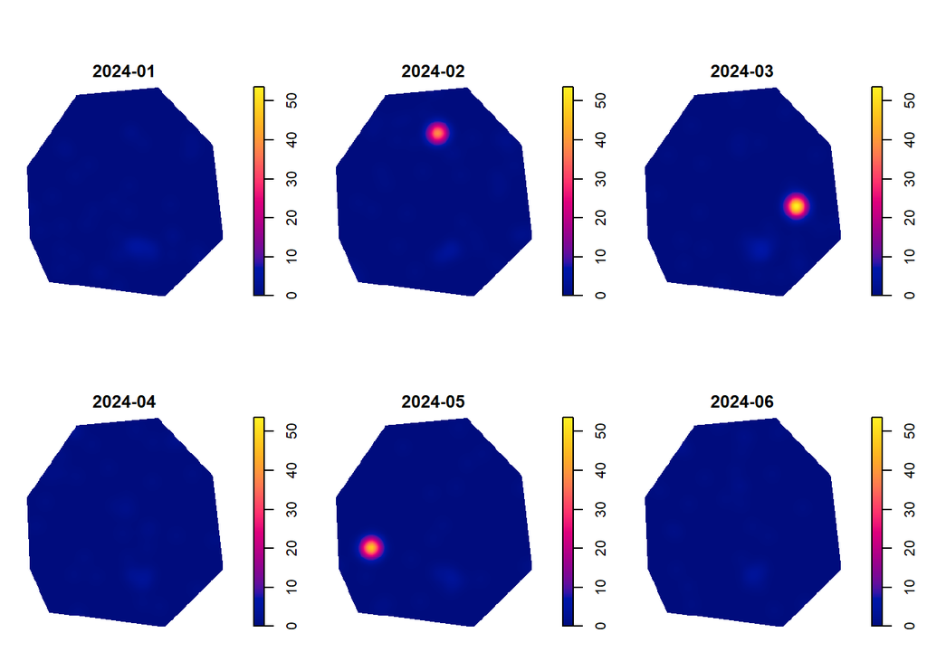

```r
cases$month <- format(cases$onset_date, "%Y-%m")
h <- 470                                 # one bandwidth, chosen in Part E

by_month <- lapply(sort(unique(cases$month)), function(m) {
  sub <- cases[cases$month == m, ]
  p   <- ppp(st_coordinates(sub)[, 1], st_coordinates(sub)[, 2], window = Window(pp))
  density(p, sigma = h, eps = 50) * 1e6
})

zmax <- max(sapply(by_month, max))        # common scale across months

par(mfrow = c(2, 3), mar = c(1, 1, 2, 2))
for (i in seq_along(by_month))
  plot(by_month[[i]], main = sort(unique(cases$month))[i], zlim = c(0, zmax))
```

```r
xy  <- st_coordinates(cases)
cube <- data.frame(E = xy[, 1], N = xy[, 2],
                   day = as.numeric(cases$onset_date - min(cases$onset_date)),
                   hood = cases$neighborhood)
```

```r
plot_ly(cube, x = ~E, y = ~N, z = ~day, color = ~hood,
        type = "scatter3d", mode = "markers",
        marker = list(size = 3, opacity = 0.75)) |>
  layout(scene = list(xaxis = list(title = "easting (m)"),
                      yaxis = list(title = "northing (m)"),
                      zaxis = list(title = "day of study")))
```

[interactive chart not shown]

```r
scatterplot3d::scatterplot3d(cube$E, cube$N, cube$day, pch = 16, cex.symbols = 0.4,
                             color = as.integer(factor(cube$hood)),
                             xlab = "easting (m)", ylab = "northing (m)", zlab = "day")
```

## Part G — The space-time K function (4 points)

Spatial clustering and space-time clustering are different claims. A neighbourhood with chronically high incidence is clustered in space in every month; an outbreak is clustered in space *and* time together. Diggle’s space-time K function separates them by comparing the joint function with the product of the two marginals:

$$D(s, t) = K_{st}(s, t) - K_s(s)\,K_t(t)$$

$D = 0$ means space and time are independent — cases may cluster spatially, temporally, or both, but not *jointly*. $D > 0$ is space-time interaction.

1. Build the inputs `splancs` expects: a two-column matrix of projected coordinates, a numeric time vector (days since the first onset), and the boundary as a matrix of vertices.
2. Compute $K_s$, $K_t$ and $K_{st}$ with `stkhat()`. Justify your choice of spatial distances `s` and time lags `tm` in one sentence each — what scales are plausible for a mosquito-borne disease?

   A: I used spatial distances from 50 m to 3000 m because mosquito-borne disease transmission can occur over short distances within neighborhoods and on larger surrounding areas. I used time lags from 3 to 70 days because this allows the analysis to detect clustering that may happen over several days or weeks.
3. Plot **both** $D(s,t)$ and the standardised version $D_0(s,t) = K_{st}/(K_s K_t) - 1$. One or two sentences on why the two surfaces have different shapes: $K$ functions are cumulative, so $D$ accumulates and then flattens, while $D_0$ measures the *proportional* excess and falls away once you leave the scale of the clustering. This is the same move as plotting $\hat{L}(r) - r$ instead of $\hat{K}(r)$ in Part D.

   A: The two surfaces have different shapes because (D(s,t)) keeps building up as distance and time increase, while (D_0(s,t)) shows how much extra clustering there is and decreases after moving past the main area of clustering
4. A surface is hard to read against nothing. Build a **permutation envelope**: shuffle the onset dates across the fixed locations, recompute $D_0$, repeat 99 times, and take the upper 97.5% quantile at each $(s, t)$. Then plot $D_0$ against $s$ as a curve per time lag, with its envelope — the space-time analogue of the envelope you used for $L$. Shuffling the dates destroys any space-time interaction while leaving both marginal patterns exactly as observed, which is the correct null here.
5. Read the peak off those curves — a distance and a lag — and say what the pair means for this disease.

   A: The peak occurs at about 50 m and 3 days. This means the strongest space-time clustering happens when dengue cases are very close together, within about 50 metres, and occur within about 3 days of each other
6. Run `stmctest()` for a single global p-value. It sums the residuals $\hat{D}(s,t)$ over the whole grid into one statistic $U$, recomputes it under permuted dates, and returns the observed value as `$t0` and the permuted ones as `$t`. Report the p-value as $(1 + \#\{t \geq t_0\}) / (1 + B)$ and plot the null distribution with the observed value marked. One sentence on what this test adds to the curves in step 4, and what it cannot tell you.

   A: The global Monte Carlo test gives one overall test of whether there is space-time interaction. It tells us whether the overall pattern is statistically different from the null pattern, but it does not tell us the specific distance and time lag where the interaction is strongest
7. Five or six sentences. Tabulate cases by neighbourhood and month. At least one neighbourhood contributes to the spatial clustering of Part D without contributing to the space-time interaction here. Identify it, explain what distinguishes it from the others, and say what each of the two patterns would mean for someone deciding where to send a vector-control team this week.

   A:El Retiro contributes to the neighborhood clustering because its case counts stay high in all six months instead of having one sudden spike.Aguablanca has a large spike in March, Floralia in February, and Siloe in May. This means El Retiro looks like a persistent spatial hotspot, while the other neighborhoods look more like short-term outbreaks. For a vector control team deciding where to go this week, the short term outbreak neighborhoods would be more urgent because they show cases concentrated in both space and time. El Retiro would still matter for longer term control because it has consistently high case counts over time.

**WarningNever report $p = 0$**

`mean(mc$t >= mc$t0)` returns 0 when no permutation beats the observed value, and 0 is not a p-value — with $B$ permutations you cannot resolve anything below $1/(B+1)$. Always add the observed value to both counts, as above. With 999 permutations the smallest reportable value is 0.001, and the honest phrasing is “$p \leq 0.001$”, not “$p < 0.0001$”.

**Note**

`splancs` is old and its arguments are terse: `stkhat(pts, times, poly, tlimits, s, tm)`, where `tlimits` is the time range, `s` the spatial distances and `tm` the time lags. `?stkhat` and `?stmctest` are short. A **Knox test** on a distance and time threshold of your choosing is an acceptable substitute if you defend both thresholds — say explicitly if you go that route.

### Starting code

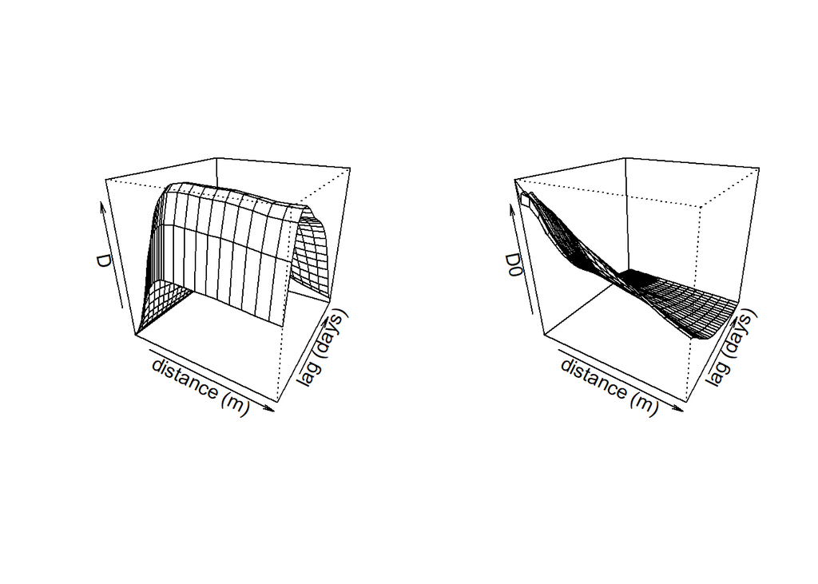

```r
xy    <- st_coordinates(cases)
pts   <- as.points(xy[, 1], xy[, 2])
times <- as.numeric(cases$onset_date - min(cases$onset_date))
bdry  <- st_coordinates(area)[, 1:2]         # drop the closing vertex if duplicated

s  <- c(seq(50, 1000, by = 50), seq(1200, 3000, by = 200))   # finer near the origin
tm <- seq(3, 70, by = 3)                     # days

stk <- stkhat(pts, times, bdry, c(0, max(times)), s, tm)

D  <- stk$kst - outer(stk$ks, stk$kt)                  # raw excess
D0 <- stk$kst / outer(stk$ks, stk$kt) - 1              # standardised excess

par(mfrow = c(1, 2))
persp(s, tm, D,  theta = 30, phi = 25,
      xlab = "distance (m)", ylab = "lag (days)", zlab = "D")
persp(s, tm, D0, theta = 30, phi = 25,
      xlab = "distance (m)", ylab = "lag (days)", zlab = "D0")
```

```r
# permutation envelope: shuffle the dates, keep the locations
B <- 99
perm <- replicate(B, {
  st <- stkhat(pts, sample(times), bdry, c(0, max(times)), s, tm)
  st$kst / outer(st$ks, st$kt) - 1
})
hi <- apply(perm, c(1, 2), quantile, 0.975)

k <- c(1, 3, 7, 14)                          # lags to show
matplot(s, D0[, k], type = "l", lty = 1, lwd = 2, xlab = "distance s (m)",
        ylab = expression(D[0](s, t)))
matlines(s, hi[, k], lty = 3, lwd = 1)
abline(h = 0, col = "grey")
legend("topright", legend = paste("lag <=", tm[k], "d"), lty = 1, lwd = 2,
       col = 1:4, bty = "n")

mc <- stmctest(pts, times, bdry, c(0, max(times)), s, tm, nsim = 999, quiet = TRUE)

(1 + sum(mc$t >= mc$t0)) / (1 + length(mc$t))   # global Monte Carlo p-value
```

```
[1] 0.001
```

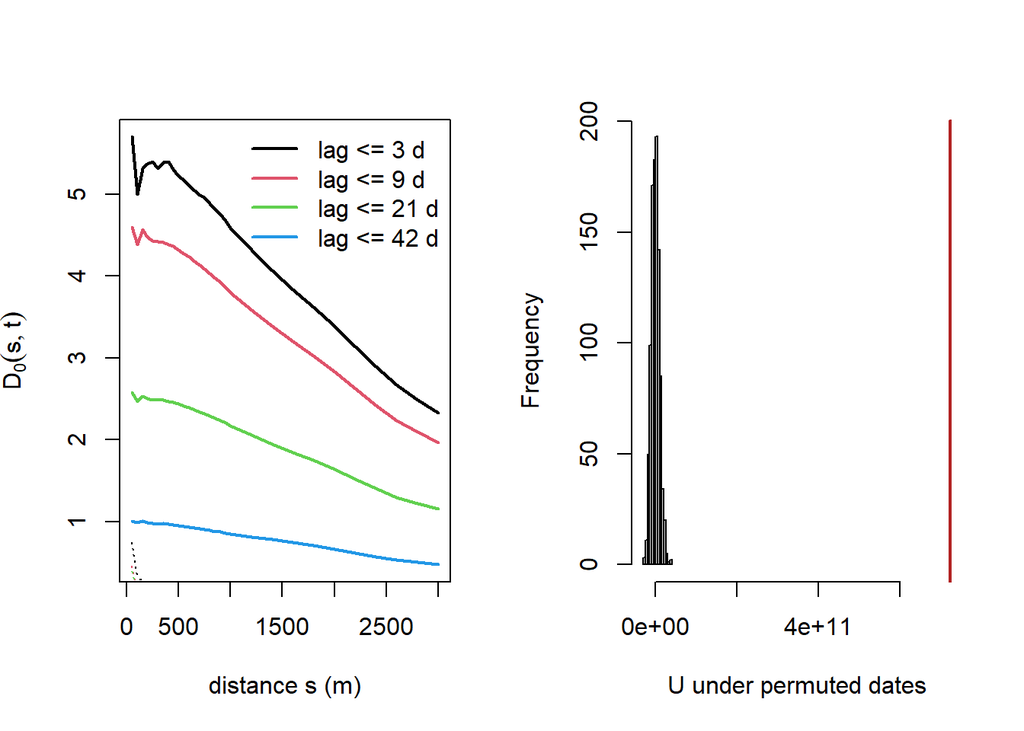

```r
hist(mc$t, xlim = range(c(mc$t, mc$t0)), xlab = "U under permuted dates", main = "")
abline(v = mc$t0, col = "firebrick", lwd = 2)
```

```r
table(cases$neighborhood, cases$month)
```

```
              2024-01 2024-02 2024-03 2024-04 2024-05 2024-06
  Aguablanca        5       7     105       5       1       2
  El Retiro        20      13      24      14      13      13
  Floralia          3      72       6       4       2       8
  La Base           3       8       1       4       4       1
  Melendez          7       4       3       3       4       2
  San Nicolas       4       4       1       5       2       5
  Siloe             6       3       3       2      84       3
  Terron            2       3       2       7       0       3
```

## Part H — Rendering and publication (1 point)

The `.qmd` is the submission, but the rendered page is what anyone else can actually read — and by the end of the semester this repository is your portfolio.

1. Render to **HTML** from a clean session, with the seed set and every package loaded explicitly, then commit both the `.qmd` and the rendered output to your semester repository, in the folder your site is built from.
2. Push, wait for GitHub Pages to rebuild, and **open the published URL yourself** to check it. A page that renders locally and 404s online is not submitted.
3. Put the URL of the published page in your document header and in your Course Site submission.

The point is for a page that works: rendered, pushed, and reachable at the URL you supply.

**WarningTwo things that break the published page**

`embed-resources: true` is already set in the header — keep it. Without it the `plotly` cube in Part F lives in a `_files/` folder that must be committed alongside the HTML, and forgetting it gives a page with a blank space where the cube should be.

Relative paths to `data/` work locally because your working directory is the `.qmd`’s folder. They will also work on the site *as long as you commit the data files*. Check the live page, not the local preview.

## AI use

End your document with a short **AI use note**: which tools, what for, at which stage. Two or three sentences.

AI use is unrestricted in this course and costs you nothing, but you must be able to explain every line you hand in. The note carries no points — it is simply expected, the way a methods section is.

A: For this assignment I used chat gpt for both the code and interpretation parts. I used chat gpt as a tutor and helped me understand the errors for the code that I had, and also got feedback on how to interpret and answer the questions. I did not copy and paste directly, only used it to guide me.

## Rubric

| Part | What is assessed | Points |
| --- | --- | --- |
| **A** | Correct import, CRS and window; `ppp` built and explained; effect of the window argued | 3 |
| **B** | VMR computed from counts; benchmark of 1 explained; resolution sweep interpreted | 3 |
| **C** | $E(d)$ derived and $R$ interpreted; Monte Carlo test correct; G compared with $R$ | 3 |
| **D** | Centred L with a simultaneous envelope; characteristic scale read and translated; stationarity assumption discussed | 4 |
| **E** | Surface in interpretable units; three bandwidths on a common scale; selectors compared; density-is-not-risk argument | 4 |
| **F** | Monthly surfaces with common bandwidth and scale; persistent vs transient hotspots named; space-time cube | 3 |
| **G** | Space-time K computed; $D_0$ with a permutation envelope; peak distance and lag read off; the spatial-only neighbourhood identified and the operational difference explained | 4 |
| **H** | Clean render to HTML, published to GitHub Pages; working URL supplied | 1 |
|  | **Total** | **25** |

Writing counts for roughly 15% within each part — more than in Exercise 1, because more of this lab is interpretation. A submission that is all code and no sentences cannot score above about 50%.

## Getting help

- Office hours, or email with the code and the exact error message.
- `splancs` in Part G is the one place where the documentation is thin. Start early enough that you can ask.
- Stuck for more than thirty minutes on something mechanical: ask rather than persevere.